# Class Questionnaire: Bootstrapping Revisited (and Some Data Cleaning)

STAT 230

January 31, 2017

## The Bootstrap

Let’s play around with some simulated data just to make things extra clear. I will start by simulating 10,000 values from a Normal distribution with mean 0 and standard deviation 1. Let’s pretend that this constitutes the population.

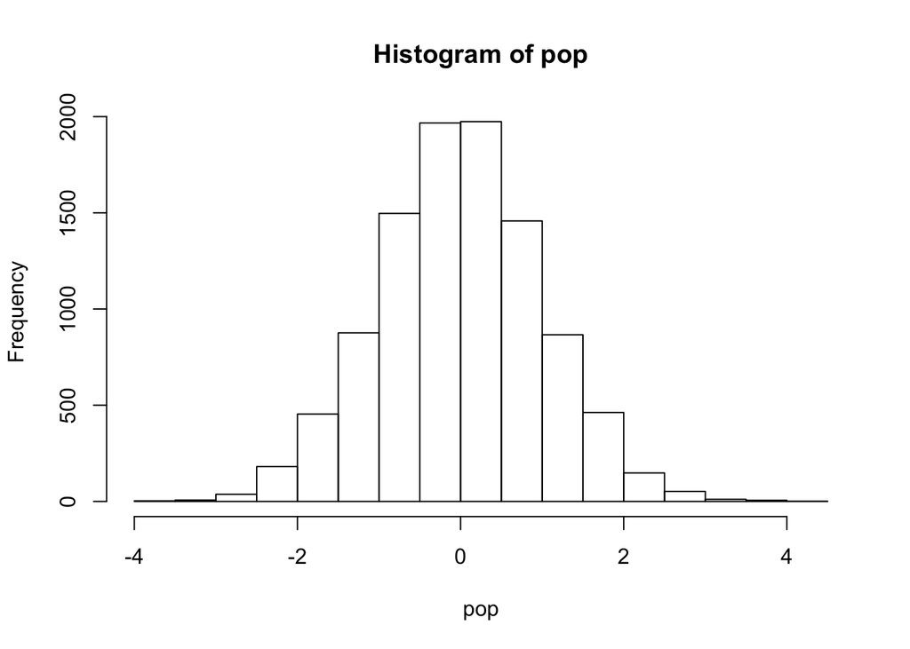

```r
set.seed(230)

pop <- rnorm(10000)
hist(pop)
```

I will now take a sample from this population (n=100):

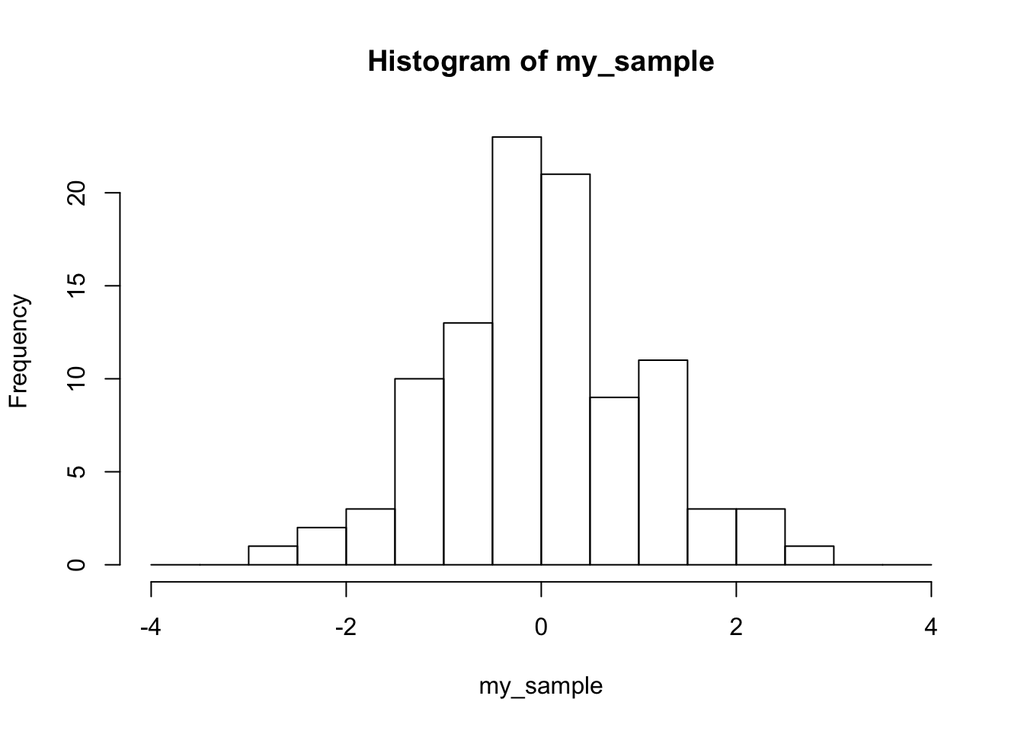

```r
my_sample <- sample(pop, 100, replace = FALSE)
hist(my_sample, breaks=seq(-4,4,by=0.5))
```

A typical one-sample inference problem might be to estimate the population mean $\mu$. Our best guess, given the data, is of course going to be the sample mean $\bar X$.

```r
mean(my_sample)
```

```
## [1] -0.006195804
```

If we want a range of values for $\mu$ that are plausible (rather than just a single point estimate), then we might take additional samples.

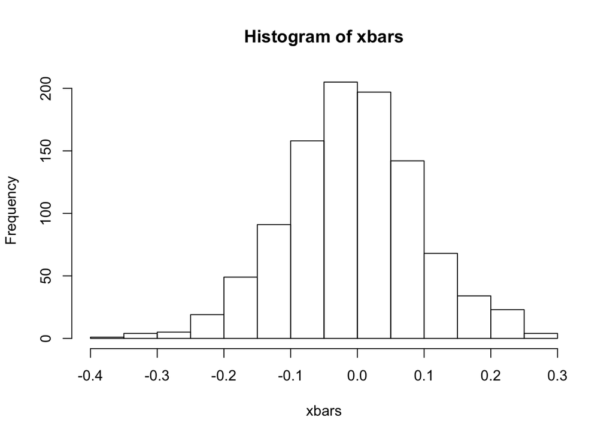

```r
xbars <- rep(NA, 1000)
for (i in 1:1000) {
  new_sample <- sample(pop, 100, replace=FALSE)
  xbars[i] <- mean(new_sample)
}
hist(xbars)
```

What we are looking at is a simulated **sampling distribution**, that is, the distribution of a sample statistic, like $\bar X$. This is easy for us to simulate because we simulated the population. In practice, this is an expensive way of obtaining an interval for $\mu$.

From the Central Limit Theorem, we know about the behavior of $\bar X$. Namely, as sample size increases, the distribution of $\bar X$ tends to a normal distribution with standard deviation $\sigma/\sqrt{n}$. Therefore, we can rely on our knowledge of probabilities under the normal distribution to compute a 95% confidence interval:

$$\bar X \pm z^*\frac{\sigma}{\sqrt{n}}$$

```r
mean(my_sample) + c(-2, 2)*1/sqrt(100)
```

```
## [1] -0.2061958  0.1938042
```

This of course, relies on the assumption that the population distribution is sufficiently symmetric (or that n=100 is large enough) such that the distribution of $\bar X$ is close to being normal (under CLT). If we felt unsure, we could use **bootstrapping** to get a confidence interval instead.

The idea is: we’d like to obtain more samples from the population to get a sense of the sampling variability. We don’t have access to the population (to sample again and again), so we’ll simply create a fake population that contains infinite copies of our sample, and sample from this fake population again and again.

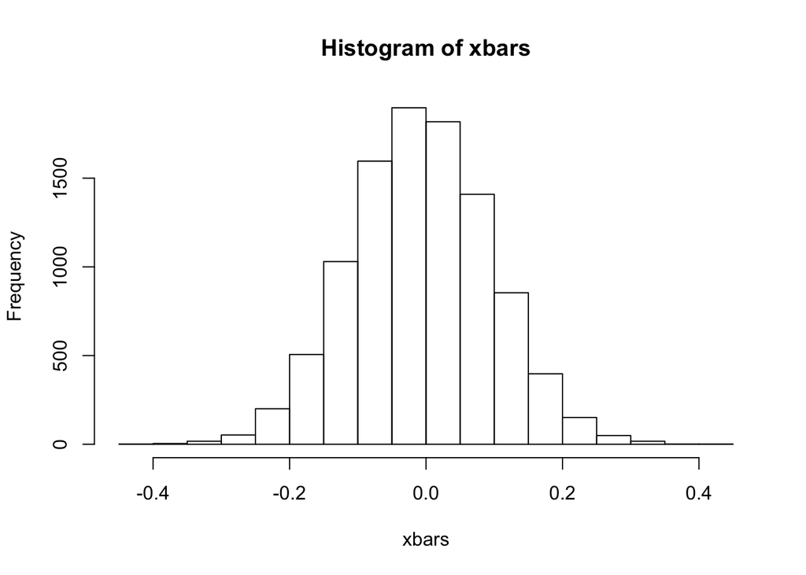

```r
N <- 10000
xbars <- rep(NA, N)
for (i in 1:N) {
  new_sample <- sample(my_sample, 100, replace = TRUE)
  xbars[i] <- mean(new_sample)
}
hist(xbars)
```

A 95% CI can be obtained by obtaining the 2.5th and 97.5th percentile of this distribution:

```r
quantile(xbars, c(0.025, 0.975))
```

```
##       2.5%      97.5%
## -0.2029903  0.1935631
```

## Back to The Pulse vs. Gender Question…

```r
x <- read.csv("stat_230_survey_raw.csv", as.is = TRUE)
x <- x[x$Gender != "" & !is.na(x$Pulse),]
```

1. Start by computing the statistic of interest.

```r
xbar_d <- mean(x$Pulse[x$Gender == "Female"]) - mean(x$Pulse[x$Gender == "Male"])
```

2. Repeatedly sample from “artificial population” with replacement and compute the statistic on each of these bootstrap samples.

```r
N <- 10000    # number of fake datasets (and statistics) to simulate
xbar_d_b <- rep(NA, N) # placeholder for the sample means from bootstrap samples
for (i in 1:N) {
  rows <- sample(1:nrow(x), replace = TRUE)
  s <- x[rows,c("Gender", "Pulse")]
  xbar_d_b[i] <- mean(s$Pulse[s$Gender == "Female"]) -
    mean(s$Pulse[s$Gender == "Male"])
}
```

```r
q <- quantile(xbar_d_b, c(0.025, 0.975))
q
```

```
##      2.5%     97.5%
## -6.019758  4.809321
```

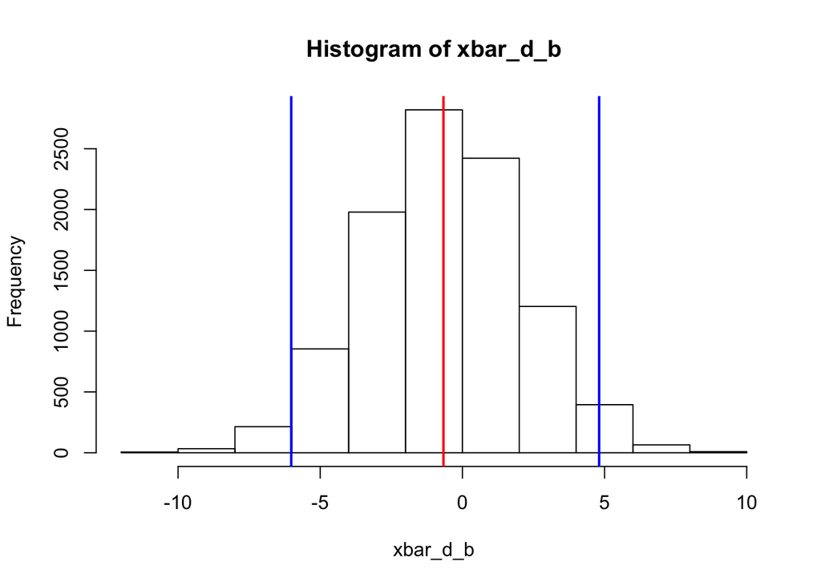

```r
hist(xbar_d_b)
abline(v=xbar_d, col="red", lwd=2)
abline(v=q, col="blue", lwd=2)
```

Compare to t-interval:

```r
t.test(Pulse ~ Gender, data=x)
```

```
##
##  Welch Two Sample t-test
##
## data:  Pulse by Gender
## t = -0.24258, df = 60.896, p-value = 0.8091
## alternative hypothesis: true difference in means is not equal to 0
## 95 percent confidence interval:
##  -6.162229  4.828895
## sample estimates:
## mean in group Female   mean in group Male
##             68.00000             68.66667
```

```r
t.test(Pulse ~ Gender, data=x)$conf
```

```
## [1] -6.162229  4.828895
## attr(,"conf.level")
## [1] 0.95
```

## And Beyond?

It’s no surprise that our bootstrap CI is very close to the t-distribution CI in this case. The sampling distribution of means are well-behaved and well-understood, and we have a decent sample size. There are cases, however, where the parameter of interest is a lot more complicated. For example, sample correlation (as in your homework) does not have as nice and straight-forward of a sampling distribution. A parametric test for the correlation exists (but to be honest, I can never remember the test statistic formula…). The non-parametric approaches for obtaining p-values and CIs are very useful in these cases.

We’ll come back to these ideas again and again as the need for them arises in other datasets.

## Data Cleaning

Data cleaning is a critical first step in most data analysis. We will spend some time cleaning up the rest of this raw dataset. Let’s start by loading in the raw data again.

```r
x <- read.csv("stat_230_survey_raw.csv", as.is = TRUE)
str(x)
```

```
## 'data.frame':    93 obs. of  24 variables:
##  $ Pcredit        : num  0.8 1 1 0.5 1 1 1 0.8 0.75 1 ...
##  $ UorG           : chr  "Graduate student" "Graduate student" "Undergraduate student" "Undergraduate student" ...
##  $ Year           : chr  "1 = freshman or first year grad" "2 = sophomore or 2nd year grad" "4 = senior or 4th year grad" "4 = senior or 4th year grad" ...
##  $ Major          : chr  "Physical sciences, engineering, or math" "Life sciences" "Social sciences" "Life sciences" ...
##  $ Gender         : chr  "Female" "Male" "Male" "Male" ...
##  $ Height         : chr  "62" "69" "75" "69" ...
##  $ Weight         : num  130 240 170 203 130 ...
##  $ Handedness     : chr  "Right handed" "Right handed" "Right handed" "Right handed" ...
##  $ Politics       : chr  "Somewhat liberal" "Moderate" "Somewhat conservative" "Somewhat liberal" ...
##  $ Political_Party: chr  "Democratic" "Other party" "Republican" "Democratic" ...
##  $ SAT_CR         : chr  "700" "740" "800" "800" ...
##  $ SAT_M          : chr  "800" "680" "780" "800" ...
##  $ SAT_W          : chr  "750" "700" "800" "790" ...
##  $ High.school.GPA: num  4 3.62 4.4 4 3.9 4 4.25 NA 3.95 4 ...
##  $ College.GPA    : num  3.8 3.7 3.95 3.92 3.9 NA 3.9 NA 3.86 3.88 ...
##  $ Television     : chr  "0" "45" "5" "38.6" ...
##  $ Web            : num  120 30 90 360 100 120 90 NA 30 60 ...
##  $ Exercise       : num  10 10 20 40 30 0 30 NA 60 30 ...
##  $ Academics      : int  240 240 240 45 360 0 120 NA 480 360 ...
##  $ Attendance     : num  0.9 0.97 1 0.95 1 0.9 1 NA 0.95 0.75 ...
##  $ Computer       : chr  "Windows" "Mac" "Mac" "Windows" ...
##  $ Pulse          : int  68 87 NA NA NA 60 72 NA 54 72 ...
##  $ Haircut        : chr  "30" "15" "20" "35" ...
##  $ TimeMachine    : chr  "30 AD" "1988" "1980" "" ...
```

We will now iterate over each of the variables in turn to check for any issues that need fixing.

```r
summary(x$Pcredit)
```

```
##    Min. 1st Qu.  Median    Mean 3rd Qu.    Max.    NA's
##  0.1000  0.8000  1.0000  0.8873  1.0000  1.0000       1
```

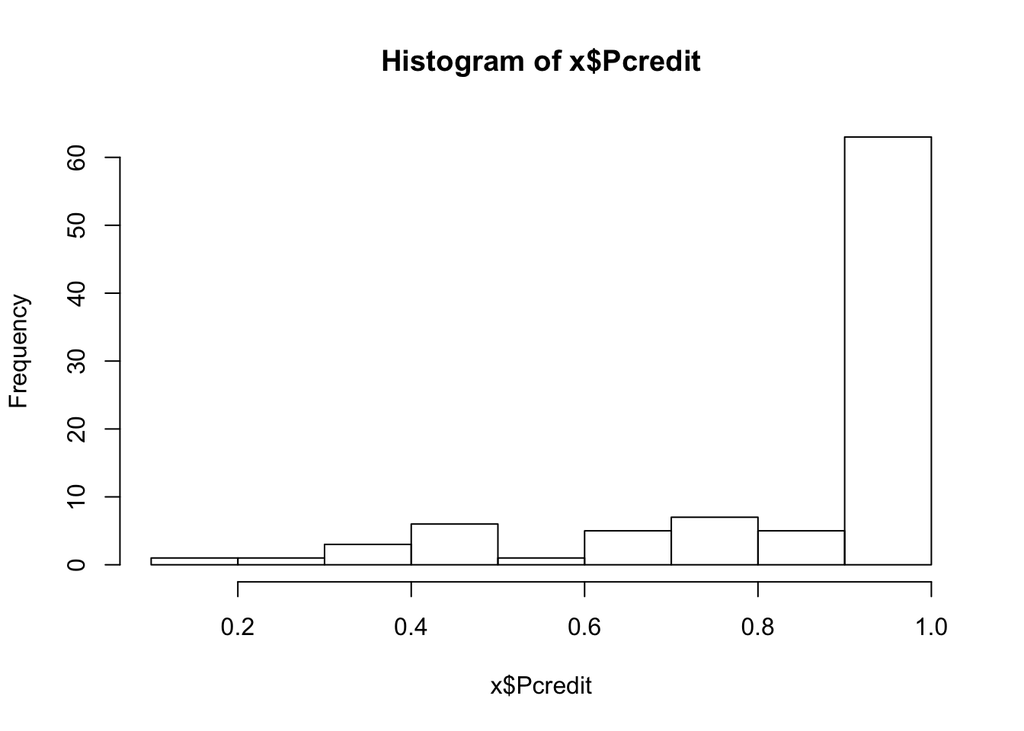

```r
hist(x$Pcredit)
```

```r
table(x$UorG)
```

```
##
##                            Graduate student               Neither
##                     1                    22                     1
## Undergraduate student
##                    69
```

There’s a missing value here… see the 1 lingering on the left? In fact, let’s take a peek at this individual.

```r
x[x$UorG == "",]
```

```
##    Pcredit UorG Year Major Gender Height Weight Handedness Politics
## 76       1                                   NA
##    Political_Party SAT_CR SAT_M SAT_W High.school.GPA College.GPA
## 76                                                 NA          NA
##    Television Web Exercise Academics Attendance Computer Pulse Haircut
## 76             NA       NA        NA         NA             NA
##    TimeMachine
## 76
```

It appears that this person only answered the first question before submitting. How do we want to handle this row? Suppose we decide we simply don’t trust the data (not even the 1 for `Pcredit`). Then, we might decide to take this row out entirely.

```r
x <- x[x$UorG != "",]
```

Now, are we satisfied with this variable? One criticism might be that the label is too long (which would be annoying in plots).

```r
table(x$UorG)
```

```
##
##      Graduate student               Neither Undergraduate student
##                    22                     1                    69
```

```r
x$UorG[x$UorG == "Graduate student"] <- "Grad"
x$UorG[x$UorG == "Undergraduate student"] <- "Undergrad"
table(x$UorG)
```

```
##
##      Grad   Neither Undergrad
##        22         1        69
```